# Leg-pain intensity in primary-care patients with sciatica

Dataset 2: Sciatica in primary care

RSR feasibility analysis

2026-08-03

# Introduction

In sciatica it is leg pain, not back pain, that defines the syndrome and that patients most want relieved; leg-pain intensity is the primary outcome in most sciatica trials and one of the few things a GP can act on at the first visit. These data come from a cross-sectional diagnostic study of 395 adults presenting to Dutch general practices with a new episode of sciatica, each of whom had a standardised history, a physical examination and a lumbar MRI (Verwoerd et al.; sciatica in general practice, MRI substudy). Knowing which history items and examination findings mark out the patients in most leg pain tells us whether severity is something the consultation can identify or whether it is essentially unexplained by the routine assessment.

**Aim.** Among primary-care patients presenting with sciatica, we examined which of age, sex, concurrent back-pain intensity, duration of the leg-pain episode, pain radiating below the knee, leg pain being worse than back pain, a positive neural-tension test and nerve-root compression on MRI are independently associated with leg-pain intensity, mutually adjusting for the others.

This is a *Purpose 3* analysis: several predictors are of interest and the question is which remain associated with the outcome after mutual adjustment.

# Methods

**Data source.** Cross-sectional baseline data from a primary-care sciatica cohort: 395 adults consulting Dutch general practitioners with a new episode of sciatica, all assessed at a single occasion. Age ranged from 19 to 82 years.

**Variables.** The outcome is `leg_pain_intensity`, average leg-pain intensity on a 0-10 numerical rating scale, where higher means worse pain. Predictors are `age_yrs` (years), `sex` (reference: female, the larger group), `back_pain_intensity` (0-10 numerical rating scale), `leg_pain_duration` (reference: under 6 weeks, the largest group), `below_knee_pain` (pain extends below the knee; reference: no), `leg_pain_worse` (patient reports leg pain worse than back pain; reference: no), `neural_tension_positive` (at least one positive neural-tension test; reference: no) and `mri_nerve_root_compression` (nerve-root compression visible on MRI; reference: no).

**Two predictor choices need justification.** First, `back_pain_intensity` is entered even though it is a pain measure like the outcome. They are related but distinct: back pain and leg pain are separately elicited on separate scales, they correlate r = 0.62 rather than 1, and 48% of patients report *more* back pain than leg pain. Including it answers a sharper question – which findings mark out severe leg pain over and above a patient’s general pain level – and excluding it would leave every other coefficient confounded by overall pain reporting. Second, `leg_pain_worse` is a patient’s own comparison of the two sites, not an arithmetic recoding of the two scores: it agrees with the sign of `leg_pain_intensity - back_pain_intensity` in only 71% of patients, so it carries independent information and is not a deterministic function of the outcome.

`id` is a participant label and is excluded from every model. `clinician_sciatica` – the GP’s high-confidence diagnosis – is deliberately **not** used. It is a summary judgement built from the same examination findings that appear as predictors here, correlating 0.61 with `neural_tension_positive` and 0.54 with `below_knee_pain`; putting it in the same model as those signs would make their coefficients uninterpretable.

**Statistical analysis.** Linear regression (`lm()`), justified because the outcome is a numerical rating scale spread across its full 0-10 range and close to symmetric. We fitted a univariable model for each predictor first, then a single multivariable model containing all of them. Predictors were chosen in advance on subject-matter grounds, not by significance. Significance threshold 0.05; estimates are reported with 95% confidence intervals. Assumptions were checked with `performance::check_model()` plus formal tests of heteroscedasticity, residual normality and collinearity; HC3 robust standard errors via `lmtest::coeftest()` with `sandwich::vcovHC()` are reported as a sensitivity check because the outcome is bounded. Analysis used R version 4.6.0 (2026-04-24) with tidyverse, gtsummary and performance.

**Missing data.** Complete-case analysis: 376 of 395 rows were analysed (19 dropped, 4.8%). Missingness in the file is confined to leg_pain_duration (19), bmi (2), back_pain_duration (2). The outcome is complete; essentially all the loss here comes from `leg_pain_duration`, the single most incomplete column in the dataset. This is the largest complete-case loss of the three outcomes analysed for this dataset, and it is entirely a consequence of including that one predictor.

# Results

## Sample characteristics

**Table 1. Sample characteristics.**

| **Characteristic** | **N** | **N = 376**<sup>1</sup> |
| --- | --- | --- |
| leg_pain_intensity | 376 | 5.33 (3.67, 7.00) |
| age_yrs | 376 | 50 (40, 60) |
| sex | 376 |  |
| Female |  | 228 (61%) |
| Male |  | 148 (39%) |
| back_pain_intensity | 376 | 5.67 (4.00, 7.00) |
| leg_pain_duration | 376 |  |
| <6 weeks |  | 165 (44%) |
| 6-12 weeks |  | 85 (23%) |
| >12 weeks |  | 126 (34%) |
| below_knee_pain | 376 | 268 (71%) |
| leg_pain_worse | 376 | 191 (51%) |
| neural_tension_positive | 376 | 234 (62%) |
| mri_nerve_root_compression | 376 | 224 (60%) |

<sup>1</sup> Median (Q1, Q3); n (%)

The analysed sample has a median leg-pain intensity of 5.3/10 with the interquartile range spanning 3.7 to 7, so leg pain is moderate to severe in most patients but far from uniformly maximal. Clinical signs are common: 71% report pain below the knee, 62% have a positive neural-tension test and 60% have nerve-root compression on MRI. Only about half say their leg pain is worse than their back pain, which is a reminder that “sciatica” in primary care is often a mixed back-and-leg presentation.

## Exploratory figure

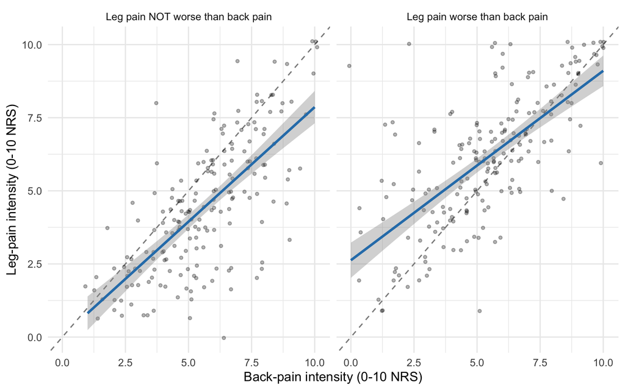

Figure 1. Leg-pain intensity against back-pain intensity, split by whether the patient reports leg pain as worse than back pain. The dashed line is equality; the solid line is a linear smooth with a 95% confidence band. Points are jittered because both scales are recorded in thirds of a point.

Leg pain and back pain rise together with a slope well below the line of equality, and the whole cloud shifts upward by roughly a point when the patient says their leg pain is the worse of the two – but the two panels overlap substantially, confirming that `leg_pain_worse` is a self-report rather than a recoding of which number is larger.

## Univariable models

| **Characteristic** | **N** | **Beta** | **95% CI** | **p-value** |
| --- | --- | --- | --- | --- |
| age_yrs | 376 | 0.01 | 0.00, 0.03 | 0.12 |
| sex | 376 |  |  |  |
| Female |  | — | — |  |
| Male |  | -0.09 | -0.59, 0.41 | 0.7 |
| back_pain_intensity | 376 | 0.69 | 0.60, 0.78 | <0.001 |
| leg_pain_duration | 376 |  |  |  |
| <6 weeks |  | — | — |  |
| 6-12 weeks |  | 0.48 | -0.15, 1.1 | 0.14 |
| >12 weeks |  | 0.57 | 0.01, 1.1 | 0.045 |
| below_knee_pain | 376 |  |  |  |
| No |  | — | — |  |
| Yes |  | 1.7 | 1.2, 2.2 | <0.001 |
| leg_pain_worse | 376 |  |  |  |
| No |  | — | — |  |
| Yes |  | 1.7 | 1.3, 2.2 | <0.001 |
| neural_tension_positive | 376 |  |  |  |
| No |  | — | — |  |
| Yes |  | 1.6 | 1.1, 2.0 | <0.001 |
| mri_nerve_root_compression | 376 |  |  |  |
| No |  | — | — |  |
| Yes |  | 1.2 | 0.69, 1.7 | <0.001 |

Abbreviation: CI = Confidence Interval